# M4A4 vs M4A1 Usage

Analysis of the effect of Valve’s nerf in Tier 1 Matches

VDK Stats

[figure not shown]

# 1 Introduction

## 1.1 Previous Articles

On the 18th of November, Valve pushed a [big update](https://blog.counter-strike.net/index.php/2022/11/40368/): Dust2 was replaced in the active map pool with Anubis, and the AWP and the M4A1-S were nerfed. Three months and several tournaments have passed since that day, so I thought it was a good momento to reflect on the effect that the patch had on the M4’s usage.

The initial reaction was fairly uniform: M4A1-S is no longer the biggest fish in the sea. Several articles were published, but one of the most completes can be found in [ESPORTS.GG](https://esports.gg/news/cs-go/m4a1-s-nerf-ct-meta-is-dead-m4a4-is-back/), where [@xL_csgo](https://twitter.com/xL_csgo) went full in depth analyzing the real impact on the changes in the range and damage of the M4A1-S. After BLAST World Finals 2022, HLTV published an [article](https://www.hltv.org/news/35254/how-have-m4-preferences-changed-following-the-silencer-nerf) confirming what everybody expected: “M4A4 has taken over as the preferred choice for the first time since the silenced version received substantial buffs to body damage in September 2021”. All the CS community welcome the new year with one idea in mind: M4A1 is no longer the clear best option, some pros even called the new M4A1 “unplayable”. You can check this really interesting interview video by HLTV if you want to get back in the time and check their initial reactions to the update: [video](https://www.youtube.com/watch?v=jdZe9122j9s).

As of today, several more tournaments with the update have been played, and we can get a glance of the real effect it had. Is the M4A1 really “unplayable”? Let’s get freaky!

## 1.2 Database Information

For this analysis I have used demos from the following tournaments: BLAST Fall Groups 2022, ESL Pro League Season 16, IEM Rio Major 2022 Challengers Stage, BLAST Fall Finals 2022, BLAST World Finals 2022, BLAST Spring Groups 2023, IEM Katowice Play In 2023 and IEM Katowice 2023. In the last four tournaments, the M4A1 update was implemented. I have not included demos from Dust2 and Anubis, since the main goal of this report is to compare the usage before and after the update. Finally, several demos that were splitted had to be omitted from the analysis. You can check the general distribution of maps in the following table:

| Tournament | Mirage | Ancient | Overpass | Inferno | Nuke | Vertigo |
| --- | --- | --- | --- | --- | --- | --- |
| BLAST Premier Fall Groups 2022 | 18 | 8 | 16 | 22 | 8 | 14 |
| ESL Pro League Season 16 | 38 | 38 | 46 | 76 | 48 | 44 |
| IEM Rio Major 2022 Challenger Stage | 18 | 8 | 16 | 22 | 8 | 14 |
| IEM Rio Major 2022 | 32 | 22 | 18 | 20 | 18 | 22 |
| BLAST Premier Fall Final 2022 | 18 | 8 | 10 | 12 | 4 | 8 |
| BLAST Premier World Finals 2022 | 14 | 6 | 4 | 20 | 10 | 2 |
| BLAST Premier Spring Groups 2023 | 22 | 16 | 24 | 30 | 12 | 10 |
| IEM Katowice 2023 | 22 | 12 | 28 | 44 | 18 | 8 |
| IEM Katowice Play In 2023 | 14 | 4 | 8 | 14 | 12 | 12 |

# 2 General Comparative

## 2.1 Kills per round evolution

Let’s begin this analysis with the most obvious information: kills per round with each weapon. In the general figure we can observe that in the first tournament after the update, the M4A4 did surpass the M4A1. However, this trend was adjusted in BLAST Premier Spring Groups, were both M4s have almost the same KPR. Moreover, in the two phases of IEM Katowice M4A1 was back on the top. Of course, one could argue that this could be explained due to a different distribution in the maps played, so let’s see if we can spot differences among the 6 maps analyzed.

### General

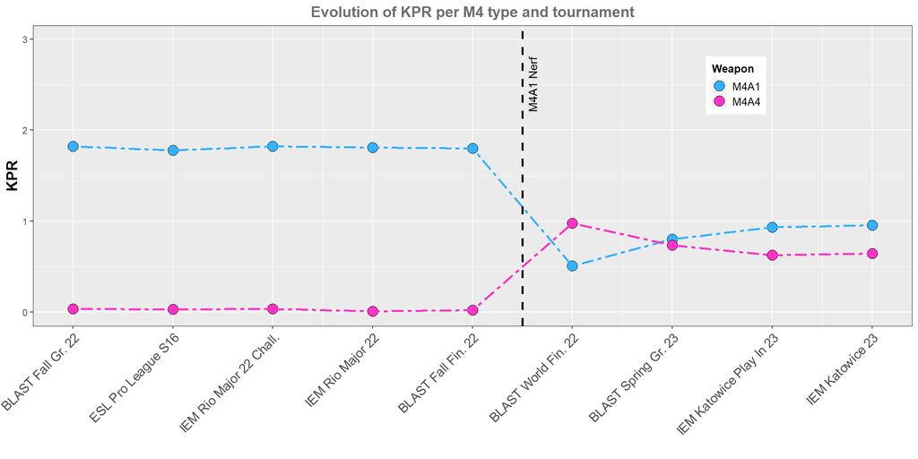

### Ancient

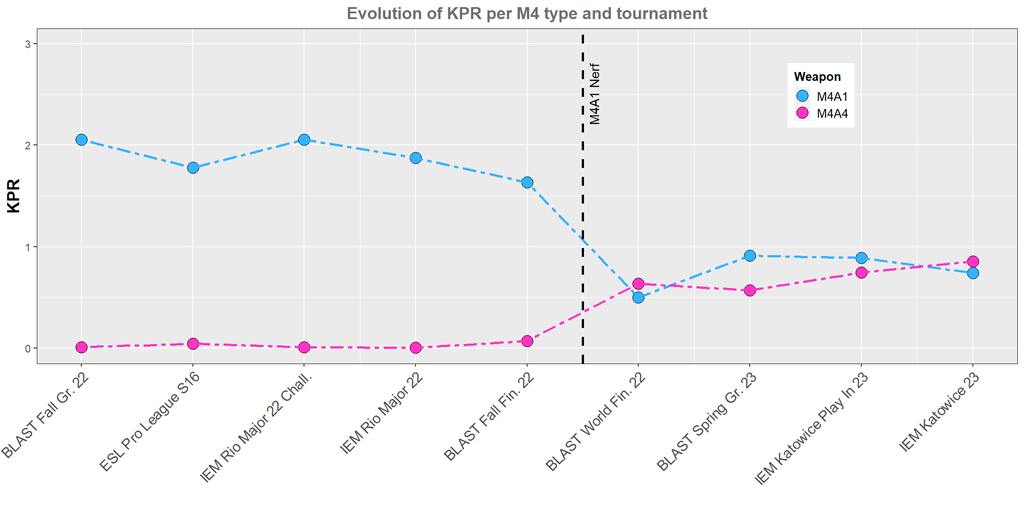

### Vertigo

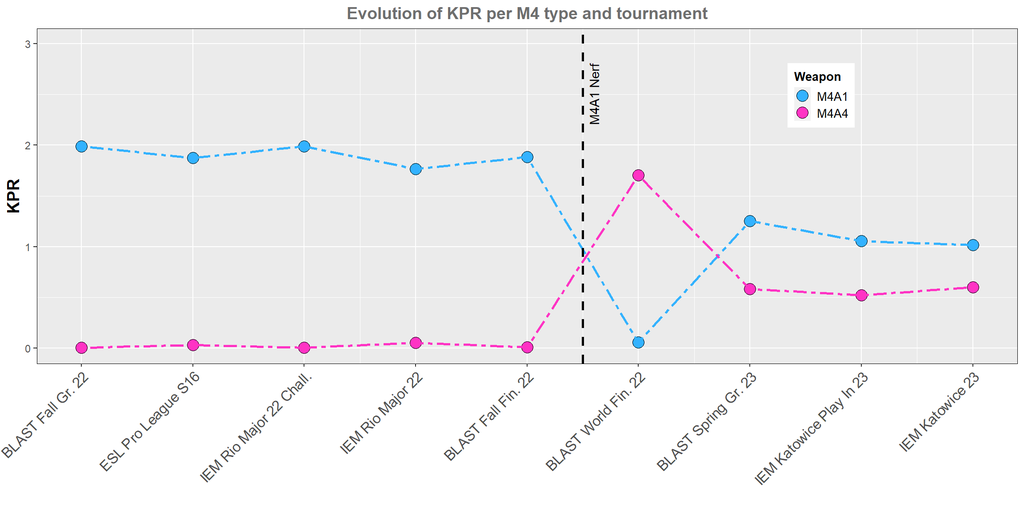

### Nuke

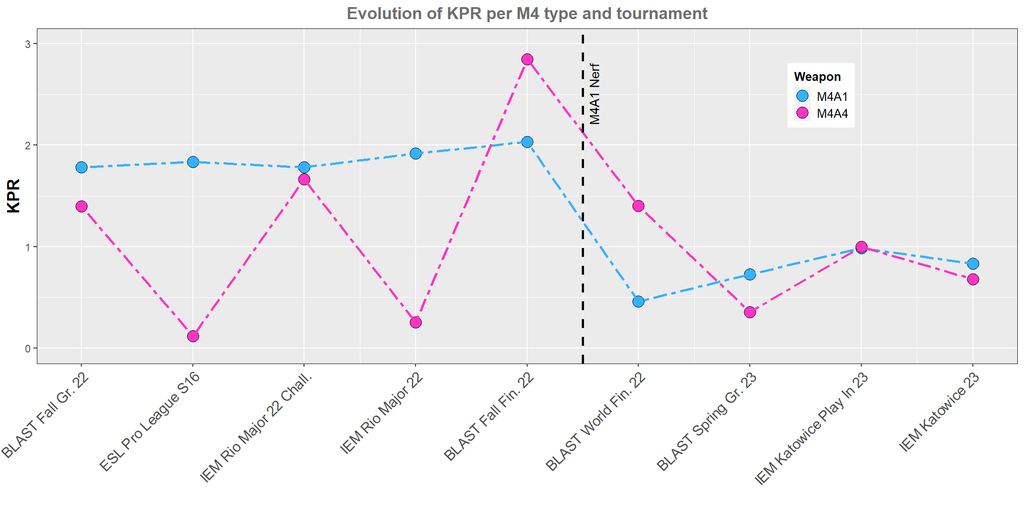

### Overpass

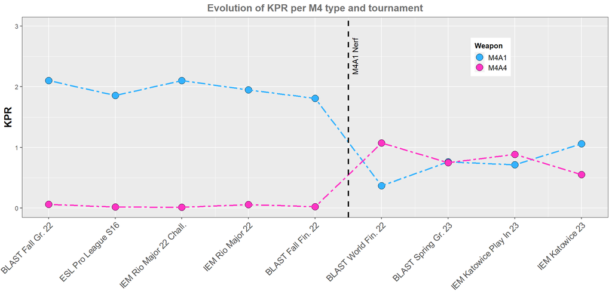

### Mirage

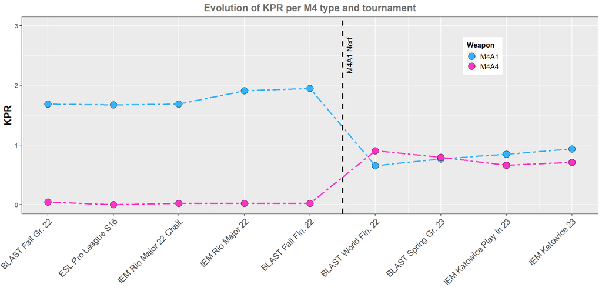

### Inferno

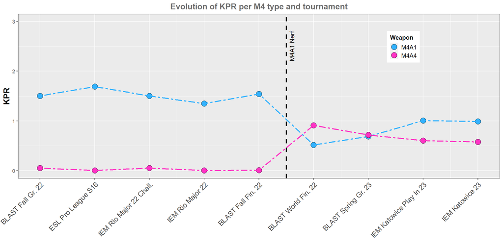

## 2.2 Distance per Kill

Another question that may arise is: does the increase accuracy of the M4A1-S give an advantage in long distance fights? In the following figures you can check that the average distance of the kills, in units, is almost the same for both M4s. Surely, this means that there is not an advantage in long distance fights. However, if we look at the boxplots in the extreme values section, there is a clear difference: the M4A1 presents way more extremely high values in tournaments before the nerf. After the nerf, it still seems to favour long range duels, but the difference is much smaller.

### 2.2.1 General Distribution

#### General

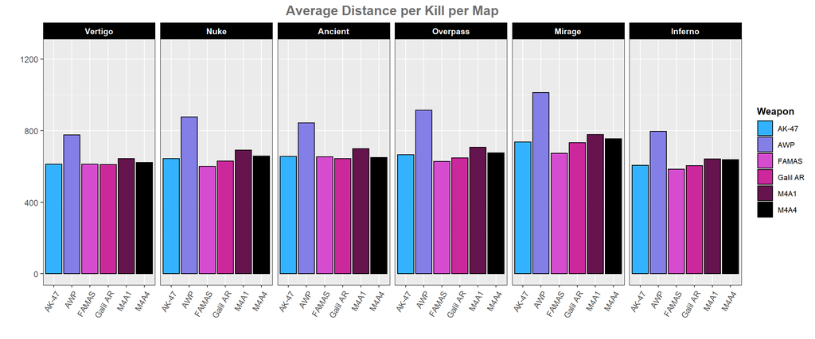

#### Pre-Nerf

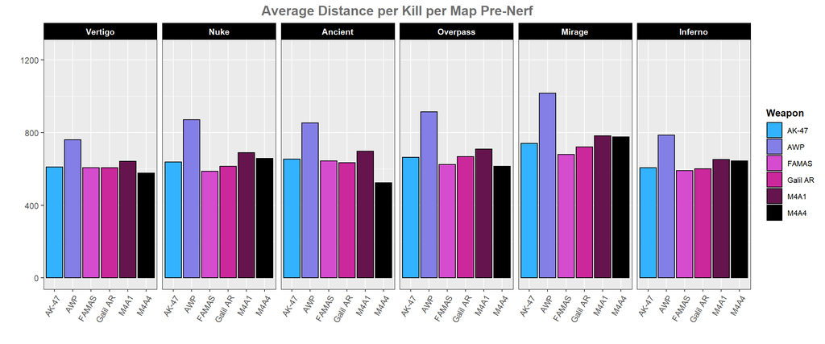

#### Post-Nerf

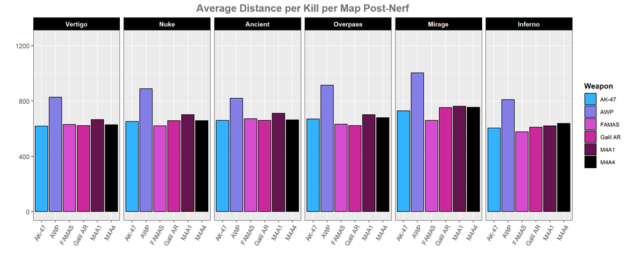

### 2.2.2 Extreme Values

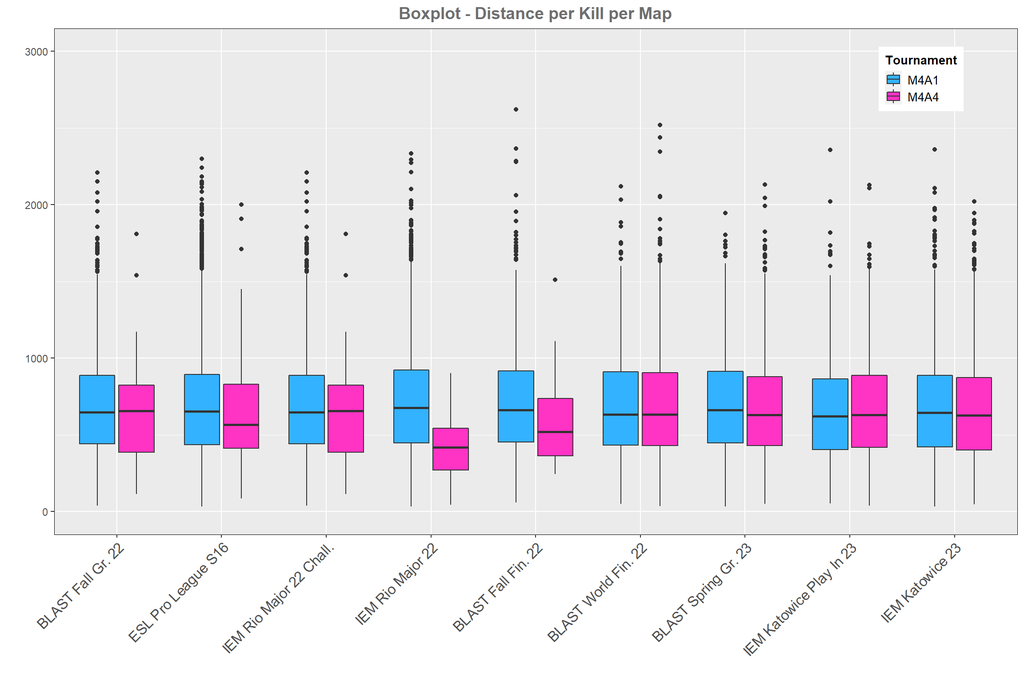

## 2.3 Entry kills per weapon

### General

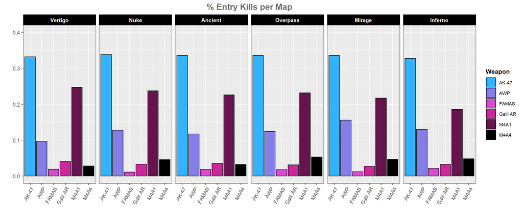

### Pre-Nerf

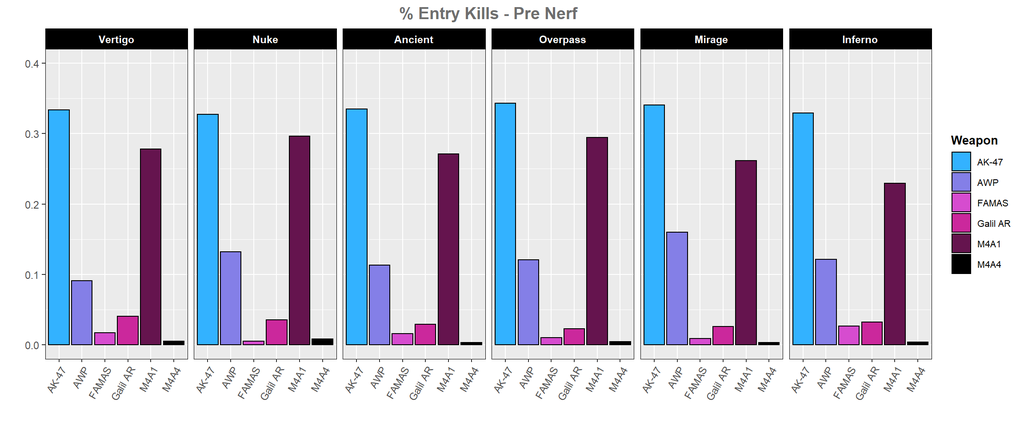

### Post-Nerf

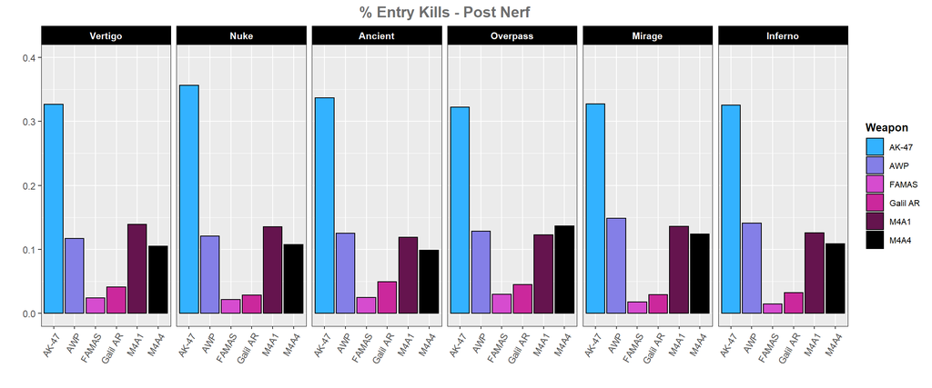

## 2.4 Kills through smokes

### General

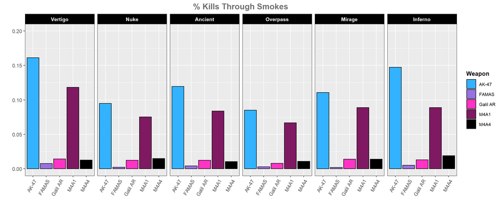

### Pre-Nerf

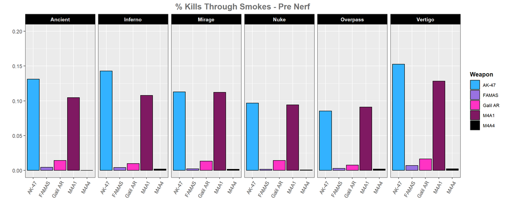

### Post-Nerf

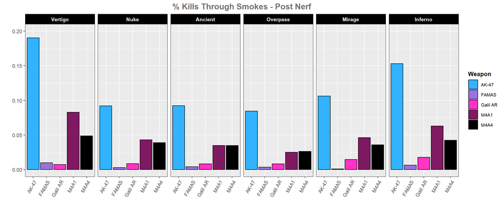

# 3 Comparison between teams

There is one final question remaining. But, what about teams? Are all teams using the same approach? Well, they are clearly NOT. In the following figures you can see the KPR per tournament with both M4s for different top tier teams. Some of them are almost at 50/50, like NaVi and Cloud9. Other are coming back to the M4A1 after the initial shock, such as Liquid, Heroic, FaZe and Vitality. Outsiders never really gave a fuck about the update, they have kept using the M4A1. But one team, only one, has fully embraced the M4A4. I think all of us can guess who without even doing this analysis: G2. Could this be one of their reasons of their recent success?

## G2 Esports

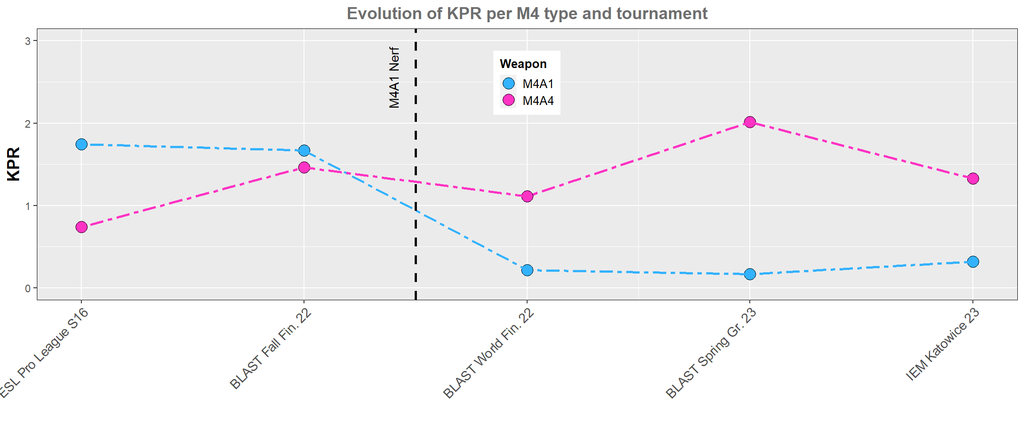

## Team Liquid

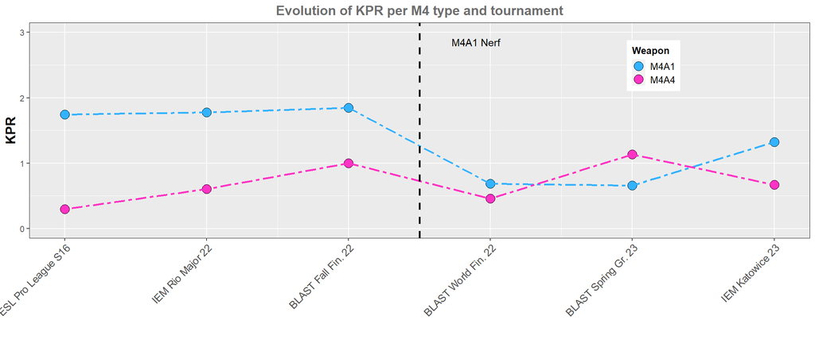

## Heroic

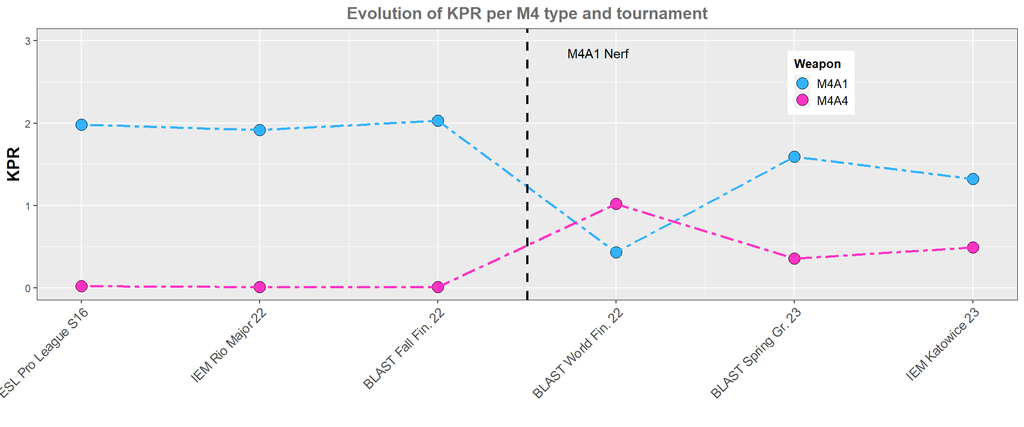

## FaZe

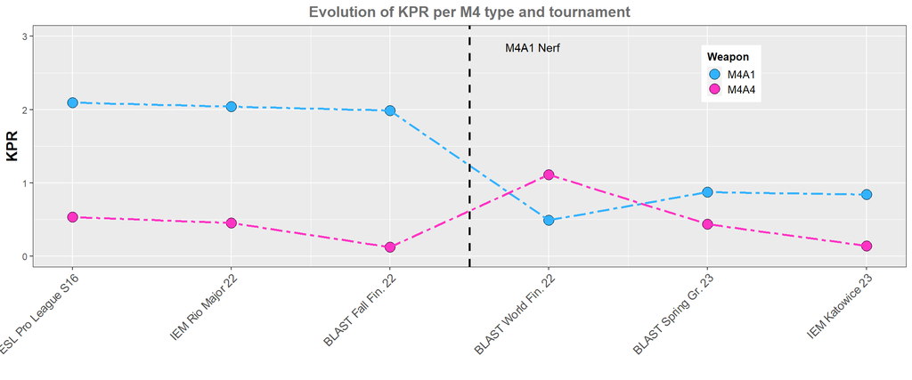

## NaVi

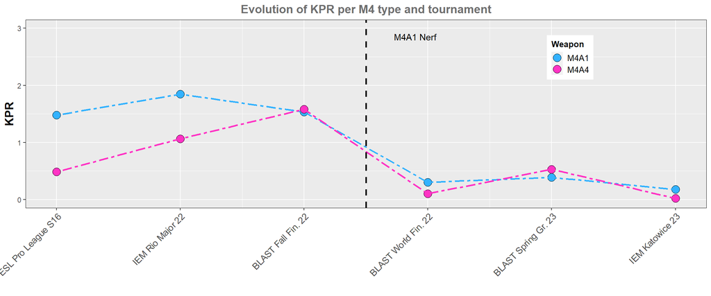

## Cloud9

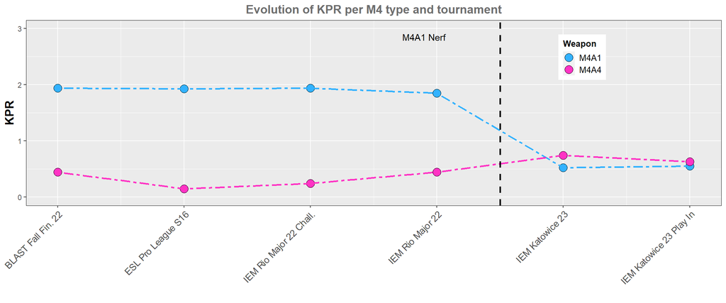

## Outsiders

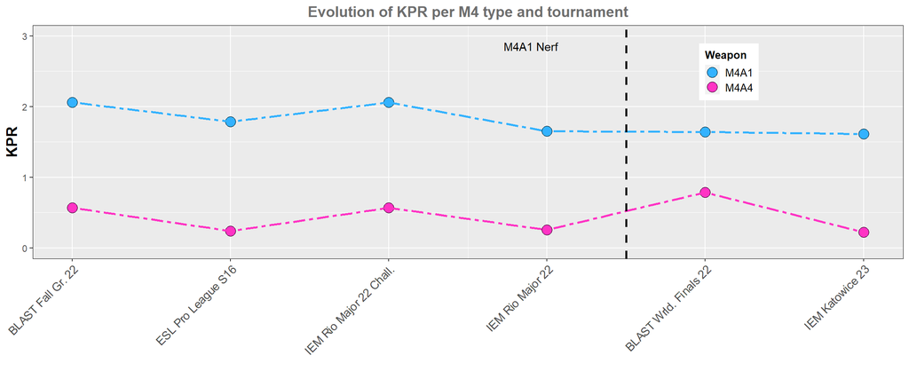

## Team Vitality

[figure not shown]

# 4 Conclusions

Finally, I would like to say thank you to all the people that have finished reading this report, I hope you found it interesting! If there is any data that does not seem correct to you please, let me know through DM or email to vdk1stats@gmail.com. The scripts used to extract the data are still being developed, I have looked at the data available at HLTV and it seems to align with my database but there could be some error somewhere that I have not figured out yet. I would like to give special thanks to [Peter Xenopoulos](https://twitter.com/peterxeno), developer of the awpy python library used to extract the data and all the people from the discord, without whose help this would not have been posible. Follow me for more content on social media!